# Introduction to `{box}`

[`klmr.me/box`](https://klmr.me/box/) [`MarEichler/rladies_box_intro`](https://github.com/MarEichler/rladies_box_intro) [`rladies_box_intro/presentation/presentation.pdf`](https://github.com/MarEichler/rladies_box_intro/blob/main/presentation/presentation.pdf)

Martha Yvonne Eichlersmith

R-Ladies Twin Cities  
March 10, 2022

# Goal of this talk

Introduce the `{box}` package and show how it can be used to write modularized/organized code and manage the name space.

**Disclaimer:** I have been using this package for about 6 months and I’m still learning new things everyday! Please ask as many questions as you want, but I may not know the answer.

### Packages Used in the Making of this Presentation/Examples

- [`{box}`](https://klmr.me/box/)
- [`{cowplot}`](https://wilkelab.org/cowplot/index.html): layout multiple plots using `plot_grid()`
- [`{glue}`](https://glue.tidyverse.org/): used to combine strings and R code (similar to `paste/paste0`)
- [`{tidyverse}`](https://www.tidyverse.org/) specifically [`{dplyr}`](https://dplyr.tidyverse.org/), [`{ggplot2}`](https://ggplot2.tidyverse.org/), [`{stringr}`](https://stringr.tidyverse.org/), and [`{tidyr}`](https://tidyr.tidyverse.org/)

# `{box}`

[figure not shown]

- [`{box}`](https://klmr.me/box/) is a relatively new package
- first version released on GitHub in July 2017
- first version on CRAN in February 2021
- Current version [1.1.0](https://cloud.r-project.org/web/packages/box/index.html) released in September 2021

# Why use `{box}`?

- Clean-up/Manage name space
- Modular-ize code without having to write full package
  - purposeful and organized code
  - if change code within box module, importation of box module doesn’t change

Box modules are like mini-packages: help re-use or share code without the much larger hurdle of developing a whole R package

- re-use code for yourself if doing similar actions frequently
- share code internally with peers/colleague (create consistency)
- share externally

# Why use `{box}`: Name Space

Name space: group of items (data frames, functions, vectors, lists, etc.) that each have a unique name.

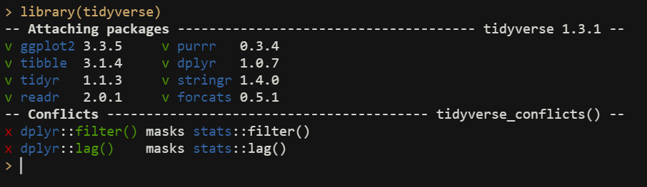

- `{dplyr}` and `{stats}` use the same name for certain functions, CONFLICT in the namespace
- If want to use the {stats} function, have to refer to the package: stats::filter()

**R Environment: Global Environment**

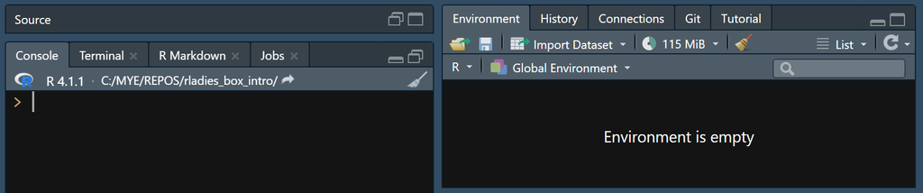

[figure not shown]

# Why use `{box}`: Modular-ize

- put code in to ‘modules’ or sections
- can have each module for a specific situation or group of functions
- other coding languages used in data science have this capability as well
  - C++ with namespace
  - Python with modules/packages
  - JavaScript with node modules

# Quick Example: Different Ways of Coding

- data set with both character and numeric variables
- two types of plots
- want to create 2 of each type of plot using different variables

*Note:* this is a simplified version of the example in the `EX_LONG` folder of the repository, using `mpg` data from the `{ggplot2}`

**A: Frequency Bar Plot**  
Character or Discrete Numeric Variables

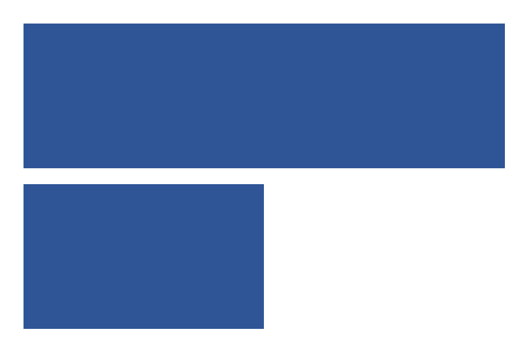

**B: Slope Plot**  
Mean of Continuous Numeric Variable at Two Points

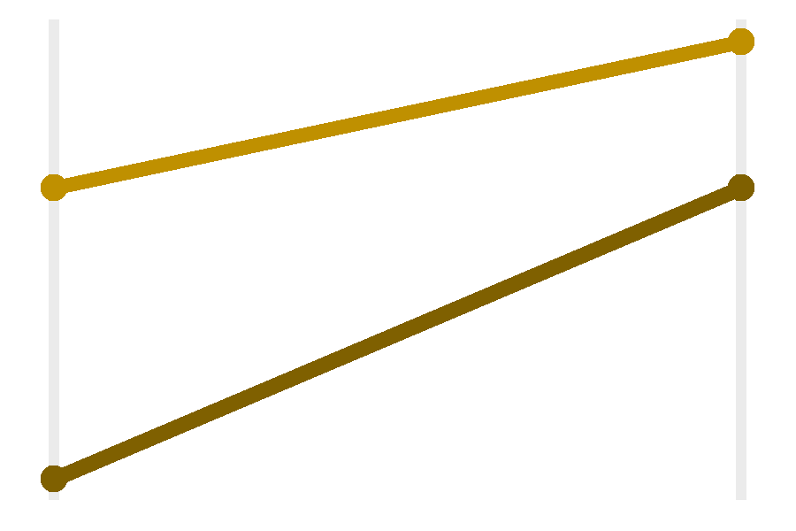

# Option 1: Write Out Code

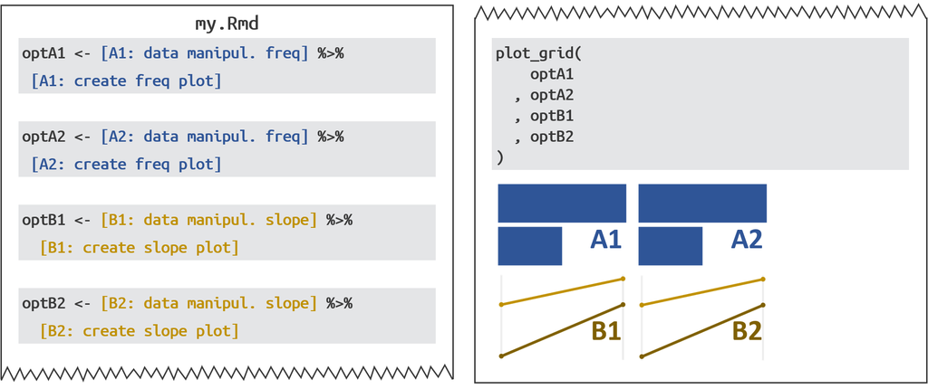

Create plots with different variables ⇒ more code (write or copy/paste)

More situations/dimensions ⇒ additional unstructured code:

- more mess and less organization
- more name space usage
- bad practice to continue to repeat code

# Option 2: Multiple Functions

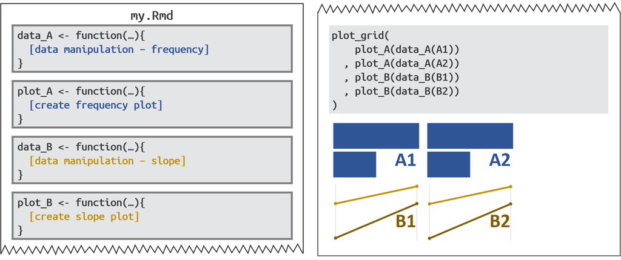

Create plots with different variables ⇒ can easily use functions

More situations/dimensions ⇒ more functions:

- more name space usage
- difficult to maintain and keep consistency (i.e. formatting across plots)

# Option 3: One Long Function

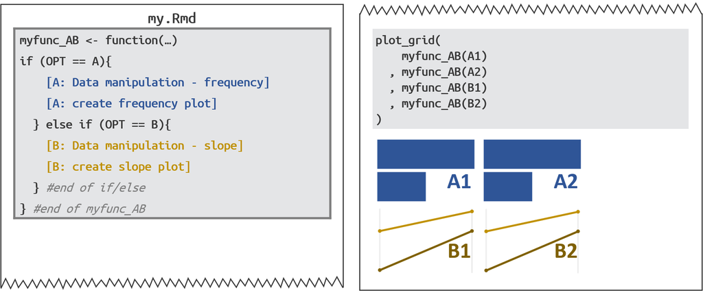

Create plots with different variables ⇒ can easily use function

More situations/dimensions ⇒ Longer function

- difficult to maintain because of large size
- difficult to test (one part of the function breaks, entire function won’t work)

# Option 4: 🌟 Box Modules 🌟

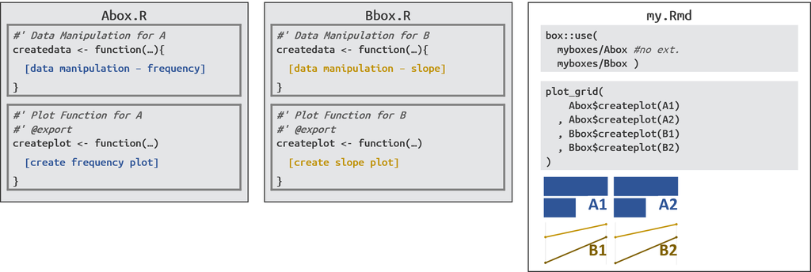

- Only box modules are in the name space
- Can use any **exported** functions
- Refer to other box modules within a specific modules

Create plots with different variables ⇒ use functions from modules

More situations/dimensions ⇒ add/amend box modules

- Test within a specific box module
- Break up long functions into multiple functions but only export the final function
- Much smaller usage of name space
- Easier to share with internally/externally

# Comparison

| Item | Option 1 Write Out Code | Option 2 Multiple Functions | Option 3 One Long Function | Option 4 Box Modules |
| --- | --- | --- | --- | --- |
| Namespace Usage | Constantly have to create unique names for objects | Only use name space for specific functions and/or dependencies | Only use name space for specific function | Only use name space for box modules |
| Testing Code | Testing code as written but shouldn’t repeat code multiple times | Functions are sectioned so can test at each level | Difficult to test individual sections once function get extremely long | All testing can be done within the module |
| Share/Re-Use | Have to piece through which code to keep and then amend to new program | Put functions together and document dependencies | One function but may be challenging to amend to a different situation or different machine | Just send the box modules `.R` files |
| Additional Dimensions | New code either added to existing code or new section, bad practice if will use multiple times | Manageable to difficult depending on how much each of the functions and their dependencies need to change | Difficult given that the function is so large, adding a new dimension would be challenging | Adjust easily within the box module or create a new box module (depending on situation) |

# Let’s learn how to use `{box}`

# Box: File/Folder Structure

- Box modules are created using `.R` files
- Keep all modules in specific folder
- Folder can be named anything (often see ‘box’ or ‘modules’)
- How you call box modules (pathways) will depend on the structure of folders
- similar to including images or sourcing another file

Examples of folder structures:

```r
EX_LONG
|
|---myboxes #folder with modules
|   |
|   |---Abox.R
|   |---admin.R
|   |---Bbox.R
|
|---my.Rmd #rmd file using box modules
```

```r
EX_SHORT
|
|---box #folder with module
|   |
|   |---greet.R
|
|---my.R #r file using box module
```

# Box: External Packages/Modules

- when starting your box module will need to use package (e.g. `{ggplot2}`, `{dplyr}`, etc.)
- may also want to use other box modules as well
- Usually load packages using `library()` command
- Need to load packages and functions with `box::use()`, NOT `library()`

`box::use` is a **universal import declaration**. It works for packages just as well as for modules. In fact, ‘box’ completely replaces the base R `library` and `require` functions. `box::use` is more explicit, more flexible, and less error-prone than `library`. At its simplest, it provides a direct replacement

[- klmr.me/box/#loading-code](https://klmr.me/box/#loading-code)

# Box: `box::use()`

Use Box Module

```r
box::use(myboxes/Abox)
```

- `myboxes`: folder where box module file is located
- `Abox`: name of box module to load (*without* the `.R` extension)

Use External Packages

```r
box::use(dplyr[...])
```

- Imports `{dplyr}` and attached all exported names
- Similar to `library(dplyr)`
- Use any `{dplyr}` functions without specifying the package name
- If just use `box::use(dplyr)`, would not be able to use functions without calling package (i.e. `dplyr::filter`)

```r
box::use(dplyr[filter, select])
```

- Imports `{dplyr}` and attaches the names `dplyr::filter` and `dplyr::select`
- Use `filter()` and `select()` from `{dplyr}`
- Would **not** be able to use `mutate()`
- Could use `dplyr::mutate()`

# Box: Write Your Functions/Code with Roxygen

- Can use anything within box modules within functions
- Only need to export the final functions you want to use outside the module
- Use [Roxygen](https://cran.r-project.org/web/packages/roxygen2/vignettes/roxygen2.html)
  - Roxygen is a way to document code, it’s used in the development of R packages
  - `#’`: before each line with information on item
  - `@param`: specifies variable inputs (each input has own line)
  - `@return`: specify output (if function)
  - `@export`: export item (REQUIRED if using outside of module)
  - `@examples`: examples of use
  - can include as many or as few as you want
  - best practice to include all but I often don’t, c’est la vie

Best practices are a *journey*, not a destination

**Roxygen Skeleton**

- Windows/Linux: Ctrl+Shift+Alt+R
- Mac: Option+Shift+Command+R
- Need to have cursor within a function

```r
#' Title
#'
#' @param [param]
#'
#' @return
#' @export
#'
#' @examples
```

# Box: Use Module Functions (EX_SHORT)

Write Code

File: `box/greet.R`

```r
box::use(
    glue[glue]
  , stringr[str_to_title]
)

#' not exported, used WITHIN only
greeting <- "Hello"

#' Greet Someone when Given a Name
#' @param name A character string
#' @return Greeting with input name
#' @export
#' @examples
#' say_hello("Martha")
say_hello <- function(name){
  to_use <- str_to_title(name)
  glue("{greeting}, {to_use}")
}
```

Import Module

File: `my.R`  
Pathway to module file,  
do not include `.R` extension

```r
box::use(
    box/greet
  )
```

Use Module!

File: `my.R`  
Use `$` to use exported functions  
(similar to `::` for packages)

```r
greet$say_hello("Martha")
```

```
## Hello, Martha
```

# Box: Tips

### Use Module after Changes

If you make changes to box module, need to **reload** module in order to changes to be in effect

```r
box::reload(Abox) #just include name, not full pathway/folder
```

Restart R Session (Shift+Ctrl+F10) and then re-run all code (including `box::use()`)

### Pathways

Use a box module **within** the same folder

```r
#within Abox.R file
box::use( ./admin)
```

```r
EX_LONG
|
|---myboxes #folder with modules
|   |
|   |---Abox.R
|   |---admin.R
|   |---Bbox.R
|
|---my.Rmd #rmd file using box modules
```

Use a box module **up a directory**

```r
#within reports/my.Rmd file
box::use( ../myboxes/admin)
```

```r
EX_LONG_REPORT_FOLDER
|
|---myboxes #folder with modules
|   |
|   |---Abox.R
|   |---admin.R
|   |---Bbox.R
|
|---reports #rmd file using box modules
    |
    |---my.Rmd
```